## In-class worksheet 5

**Feb 3, 2015**

## 1. Tidy data

*Is the `iris` dataset tidy? Explain why or why not.*

```r
head(iris)
```

```
##   Sepal.Length Sepal.Width Petal.Length Petal.Width Species
## 1          5.1         3.5          1.4         0.2  setosa
## 2          4.9         3.0          1.4         0.2  setosa
## 3          4.7         3.2          1.3         0.2  setosa
## 4          4.6         3.1          1.5         0.2  setosa
## 5          5.0         3.6          1.4         0.2  setosa
## 6          5.4         3.9          1.7         0.4  setosa
```

It is tidy. All variables correspond to one column each, and each row in the data set corresponds to one observational unit (flower).

## 2. Selecting rows and columns

*Pick all the rows in the `iris` dataset that pertain to species setosa, and store them in a new table called `iris.setosa`.*

```r
iris %>% filter(Species=='setosa') -> iris.setosa
head(iris.setosa)
```

```
##   Sepal.Length Sepal.Width Petal.Length Petal.Width Species
## 1          5.1         3.5          1.4         0.2  setosa
## 2          4.9         3.0          1.4         0.2  setosa
## 3          4.7         3.2          1.3         0.2  setosa
## 4          4.6         3.1          1.5         0.2  setosa
## 5          5.0         3.6          1.4         0.2  setosa
## 6          5.4         3.9          1.7         0.4  setosa
```

*Pick all the rows in the `iris` dataset where species virginica has a sepal length > 7.*

```r
iris %>% filter(Sepal.Length>7 & Species=='virginica')
```

```
##    Sepal.Length Sepal.Width Petal.Length Petal.Width   Species
## 1           7.1         3.0          5.9         2.1 virginica
## 2           7.6         3.0          6.6         2.1 virginica
## 3           7.3         2.9          6.3         1.8 virginica
## 4           7.2         3.6          6.1         2.5 virginica
## 5           7.7         3.8          6.7         2.2 virginica
## 6           7.7         2.6          6.9         2.3 virginica
## 7           7.7         2.8          6.7         2.0 virginica
## 8           7.2         3.2          6.0         1.8 virginica
## 9           7.2         3.0          5.8         1.6 virginica
## 10          7.4         2.8          6.1         1.9 virginica
## 11          7.9         3.8          6.4         2.0 virginica
## 12          7.7         3.0          6.1         2.3 virginica
```

*Are there any cases in this data set for which the ratio of sepal length to sepal width exceeds the ratio of petal length to petal width? Use `filter()` to find out.*

```r
iris %>% filter(Sepal.Length/Sepal.Width > Petal.Length/Petal.Width)
```

```
##   Sepal.Length Sepal.Width Petal.Length Petal.Width   Species
## 1          6.9         3.1          5.1         2.3 virginica
```

There is exactly one such observation, for species virginica.

*Create a pared-down table which contains only data for species setosa and which only has the columns `Sepal.Length` and `Sepal.Width`. Store the result in a table called `iris.pared`.*

```r
iris %>% filter(Species=='setosa') %>%
  select(Sepal.Length, Sepal.Width) -> iris.pared
head(iris.pared)
```

```
##   Sepal.Length Sepal.Width
## 1          5.1         3.5
## 2          4.9         3.0
## 3          4.7         3.2
## 4          4.6         3.1
## 5          5.0         3.6
## 6          5.4         3.9
```

## 3. Grouping and summarizing

*Calculate the mean and standard deviation of the sepal lengths for each species.*

```r
iris %>% group_by(Species) %>%
  summarize(mean.sepal.length = mean(Sepal.Length), sd.sepal.length = sd(Sepal.Length))
```

```
## Source: local data frame [3 x 3]
##
##      Species mean.sepal.length sd.sepal.length
## 1     setosa             5.006          0.3525
## 2 versicolor             5.936          0.5162
## 3  virginica             6.588          0.6359
```

*Count the number of observations for each species.*

```r
iris %>% group_by(Species) %>%
  summarize(count = n())
```

```
## Source: local data frame [3 x 2]
##
##      Species count
## 1     setosa    50
## 2 versicolor    50
## 3  virginica    50
```

*For each species, calculate the percentage of cases with sepal length > 5.5.*

```r
iris %>% group_by(Species) %>%
  summarize(percent = sum(Sepal.Length>5.5)/n())
```

```
## Source: local data frame [3 x 2]
##
##      Species percent
## 1     setosa    0.06
## 2 versicolor    0.78
## 3  virginica    0.98
```

## 4. Creating new data, arranging

*Order the data in the `iris` table from largest to smallest sepal length.*

```r
iris %>% arrange(desc(Sepal.Length)) %>% head()
```

```
##   Sepal.Length Sepal.Width Petal.Length Petal.Width   Species
## 1          7.9         3.8          6.4         2.0 virginica
## 2          7.7         3.8          6.7         2.2 virginica
## 3          7.7         2.6          6.9         2.3 virginica
## 4          7.7         2.8          6.7         2.0 virginica
## 5          7.7         3.0          6.1         2.3 virginica
## 6          7.6         3.0          6.6         2.1 virginica
```

*Create a data column that holds the ratio of sepal length to sepal width. Then order the data by species name and by increasing values of sepal length-to-width ratio. Store the result in a table called `iris.ratio`*

```r
iris %>% mutate(sepal.length.to.width = Sepal.Length/Sepal.Width) %>%
  arrange(Species, sepal.length.to.width) -> iris.ratio
head(iris.ratio)
```

```
##   Sepal.Length Sepal.Width Petal.Length Petal.Width Species
## 1          5.2         4.1          1.5         0.1  setosa
## 2          4.6         3.6          1.0         0.2  setosa
## 3          5.7         4.4          1.5         0.4  setosa
## 4          5.5         4.2          1.4         0.2  setosa
## 5          5.1         3.8          1.5         0.3  setosa
## 6          5.1         3.8          1.9         0.4  setosa
##   sepal.length.to.width
## 1                 1.268
## 2                 1.278
## 3                 1.295
## 4                 1.310
## 5                 1.342
## 6                 1.342
```

## 5. If this was easy

*Take the `iris.ratio` data set you have created and plot the distribution of sepal length-to-width ratios for the three species.*

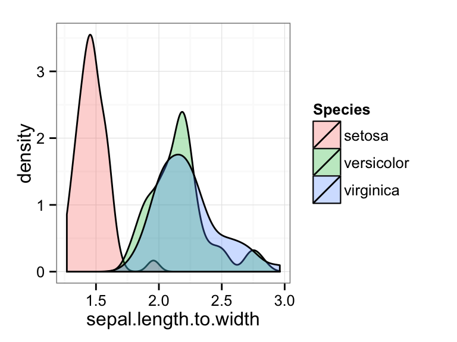

```r
ggplot(iris.ratio, aes(x=sepal.length.to.width, fill=Species)) + geom_density(alpha=.3)
```

*Now plot sepal length-to-width ratios vs. sepal lengths. Does it look like there is a relationship between the length-to-width ratios and the lengths? Does it matter whether you consider each species individually or all together? How could you find out?*

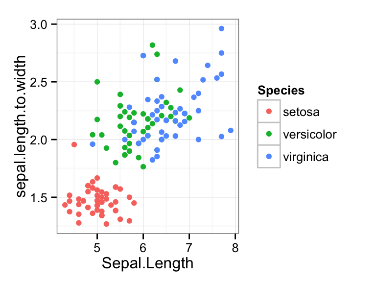

```r
ggplot(iris.ratio, aes(y=sepal.length.to.width, x=Sepal.Length, color=Species)) + geom_point()
```

There seems to be an overall trend of increasing length-to-width ratio with increasing length, but it seems that within each species there is little correlation between these values. We can check this by running a correlation analysis for each species:

```r
# Setosa
iris.ratio %>% filter(Species=='setosa') -> setosa.ratio
cor.test(setosa.ratio$Sepal.Length, setosa.ratio$sepal.length.to.width)
```

```
##
##  Pearson's product-moment correlation
##
## data:  setosa.ratio$Sepal.Length and setosa.ratio$sepal.length.to.width
## t = -1.122, df = 48, p-value = 0.2675
## alternative hypothesis: true correlation is not equal to 0
## 95 percent confidence interval:
##  -0.4195  0.1240
## sample estimates:
##     cor
## -0.1598
```

```r
# Versicolor
iris.ratio %>% filter(Species=='versicolor') -> versicolor.ratio
cor.test(versicolor.ratio$Sepal.Length, versicolor.ratio$sepal.length.to.width)
```

```
##
##  Pearson's product-moment correlation
##
## data:  versicolor.ratio$Sepal.Length and versicolor.ratio$sepal.length.to.width
## t = 1.752, df = 48, p-value = 0.08613
## alternative hypothesis: true correlation is not equal to 0
## 95 percent confidence interval:
##  -0.03559  0.49008
## sample estimates:
##    cor
## 0.2452
```

```r
# Virginica
iris.ratio %>% filter(Species=='virginica') -> virginica.ratio
cor.test(virginica.ratio$Sepal.Length, virginica.ratio$sepal.length.to.width)
```

```
##
##  Pearson's product-moment correlation
##
## data:  virginica.ratio$Sepal.Length and virginica.ratio$sepal.length.to.width
## t = 3.502, df = 48, p-value = 0.001011
## alternative hypothesis: true correlation is not equal to 0
## 95 percent confidence interval:
##  0.1975 0.6480
## sample estimates:
##    cor
## 0.4511
```

Virginica shows a significant correlation between sepal length and length-to-width ratio, the other two species do not.

**Note:** The last analysis could be automated so that the correlation test is automatically run over all species in the data frame, using the function `do()`. However, the code may be a little confusing if you’re new to R. Don’t worry if this doesn’t make sense to you.

```r
iris.ratio %>% group_by(Species) %>%
  do(cor.res = cor.test(.$Sepal.Length, .$sepal.length.to.width)) -> cors
do(cors, data.frame(species=.$Species, cor=.$cor.res$estimate, p=.$cor.res$p.value))
```

```
## Source: local data frame [3 x 3]
## Groups: <by row>
##
##      species     cor        p
## 1     setosa -0.1598 0.267540
## 2 versicolor  0.2452 0.086132
## 3  virginica  0.4511 0.001011
```